# 資料視覺化期末報告 - 2017七期三次問卷I 社會階層

心理108 王苡蓁

2019/1/12

# 階層分類

- 本次報告想要探討「人是依據哪些客觀因素來區分自己的社會階層」
- 試圖從教育程度、月薪、快樂程度、對人的信任度了解不同階級的差異性

# 主觀階層分類

- 為了探討不同階級在各個變項間的差異，選用E部分「階級與選舉行為」中的E2作為主軸
- E2.題目：假如把社會上所有的人分成上層、中上層、中層、中下層、勞工階級和下層階級，請問您認為 您屬於哪個階級?
- 先將資料合併成以下四階級，進行後續分析
1. 勞工階級
2. 下層階級：下層、中下層
3. 中層階級
4. 上層階級：上層、中上層

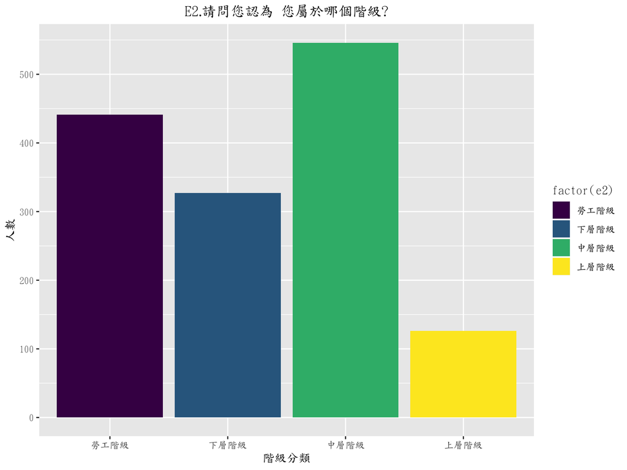

# 各階層的快樂程度

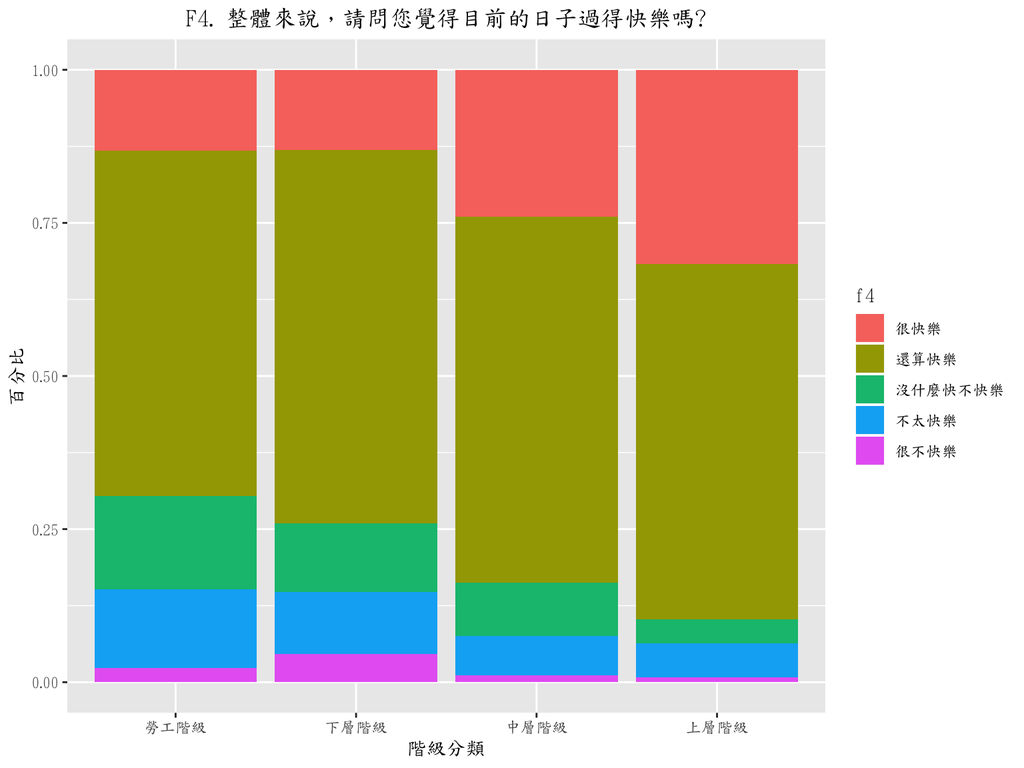

# 各階層對人的信任程度

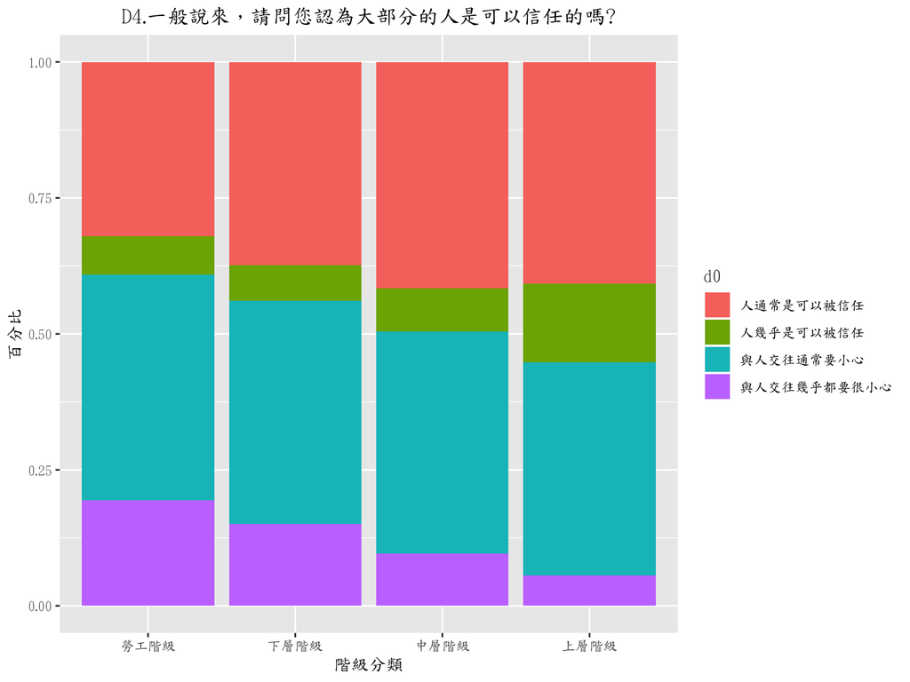

# 各階層的教育程度

- 為了瞭解不同階層在教育程度上的差異，選用問卷B部分「教育與婚姻狀況」的問題B1
- B1.題目：**請問您的教育程度是？**
- 再根據[中華民國教育程度標準分類](http://stats.moe.gov.tw/files/bcode/105bcode_book.pdf)，把學歷變項區分成8個項目：
1. 無/不識字
2. 國民小學
3. 國民中學
4. 高級中等： 包含高中、高職
5. 副學士(專科)： 包含二專、三專、空中商專、警專…等
6. 學士： 包含大學、空中大學、五專
7. 碩士
8. 博士

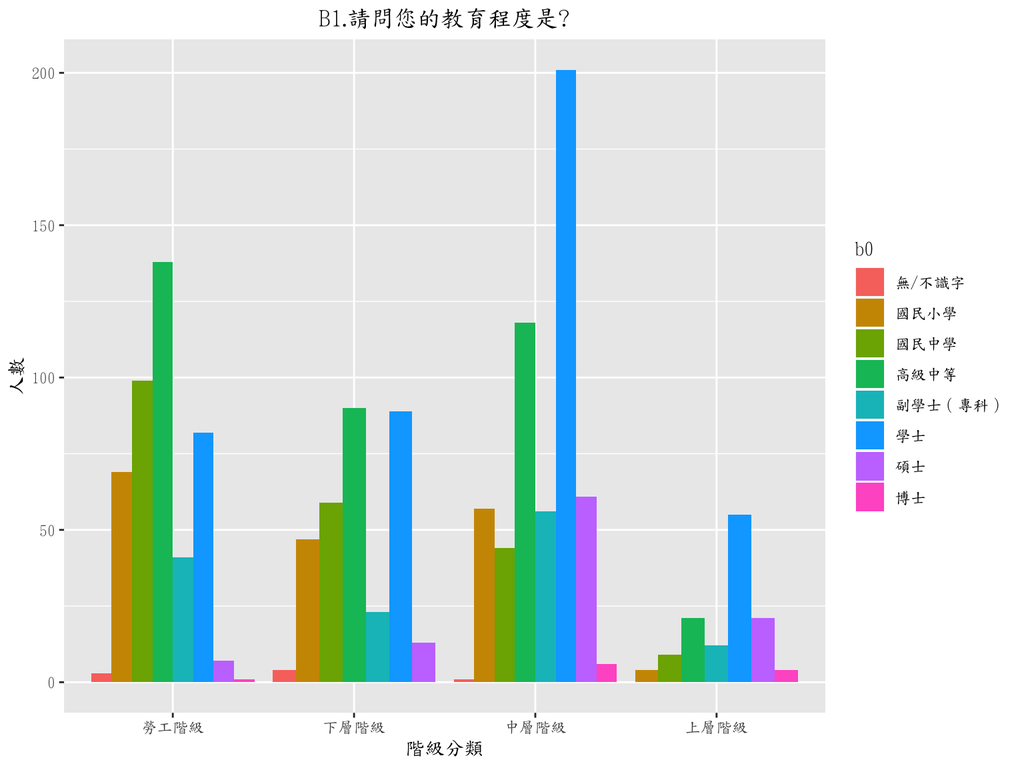

# 各階層教育程度百分比

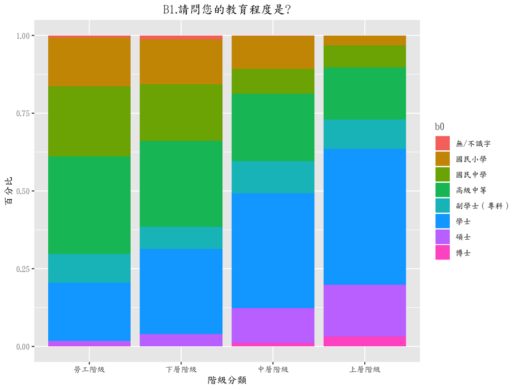

# 所有階層的月薪比例

- 為了瞭解不同階層月薪差異，使用問卷的C24題作圖
- C24.題目：請問您目前(退休前/最後一個)這個工作或職務平均每月所有的工作收入(稅前)差不多有多少? (含兼差，包括薪資、年終獎金、年節分紅、加班費、執行業務收入、自營收入等)
- 此圖涵蓋所有階層的月薪分佈，接下來會針對各階層獨立做圖

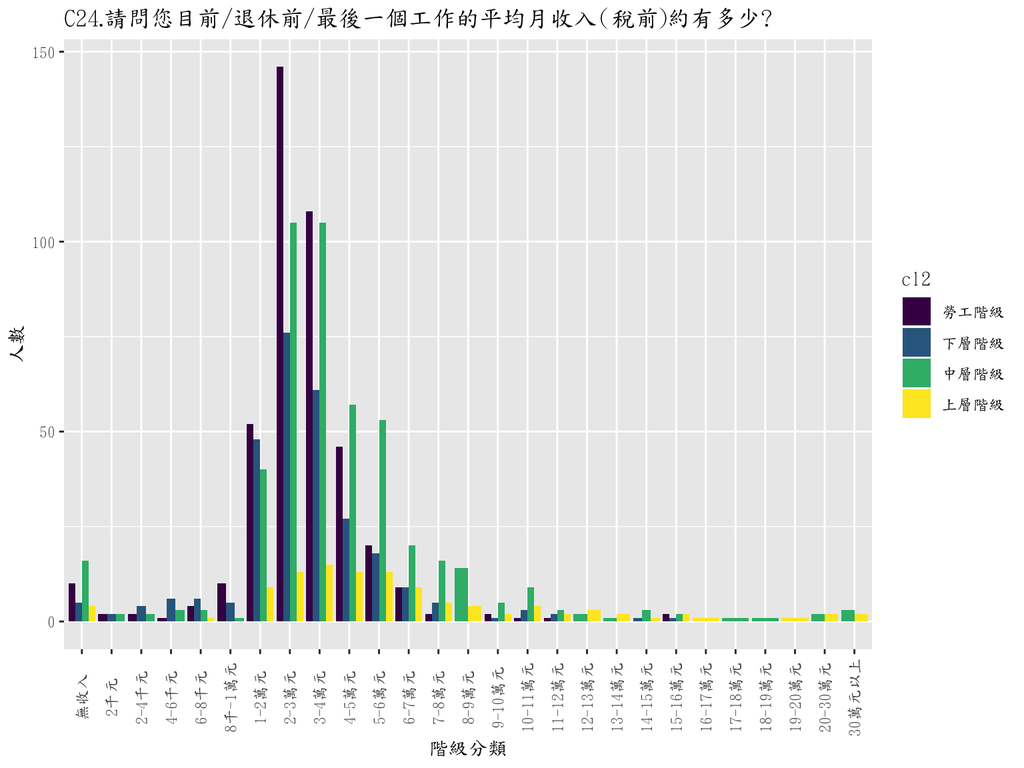

# 勞工階級的月薪分佈

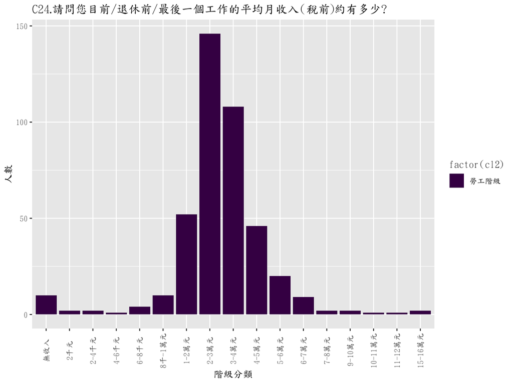

# 下層階級的月薪分佈

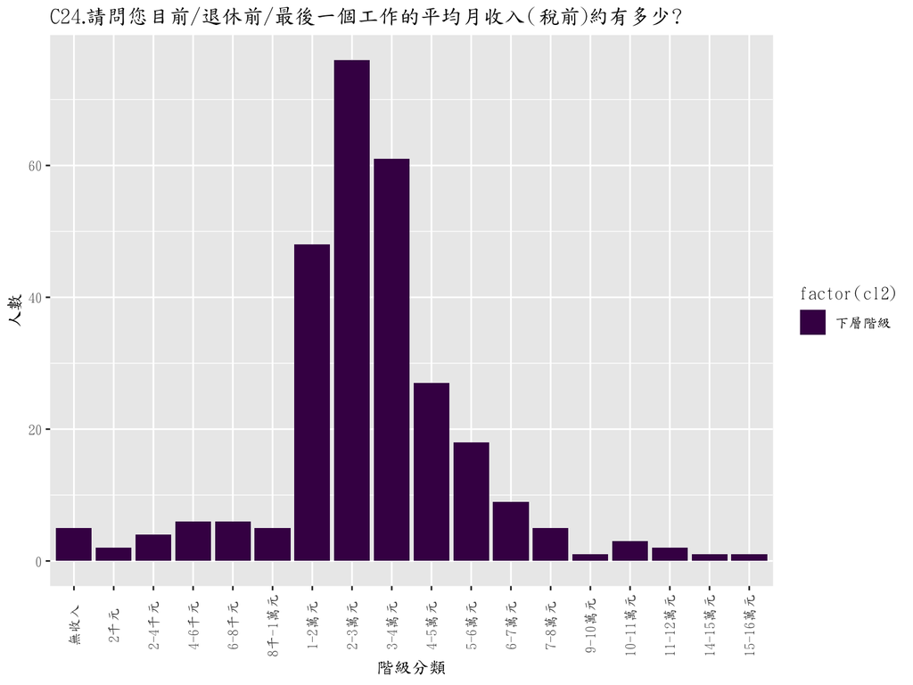

# 中層階級的月薪分佈

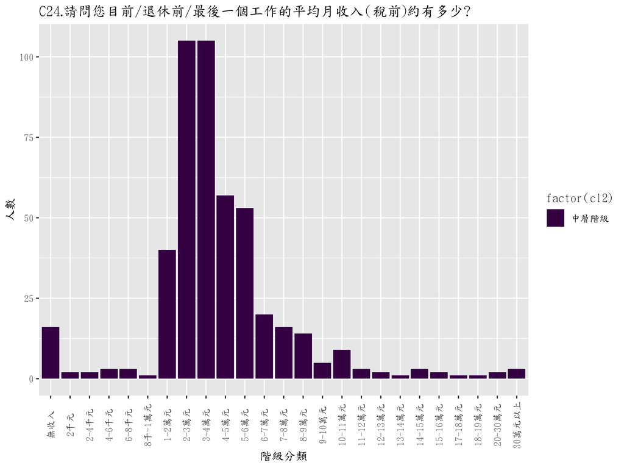

# 上層階級的月薪分佈

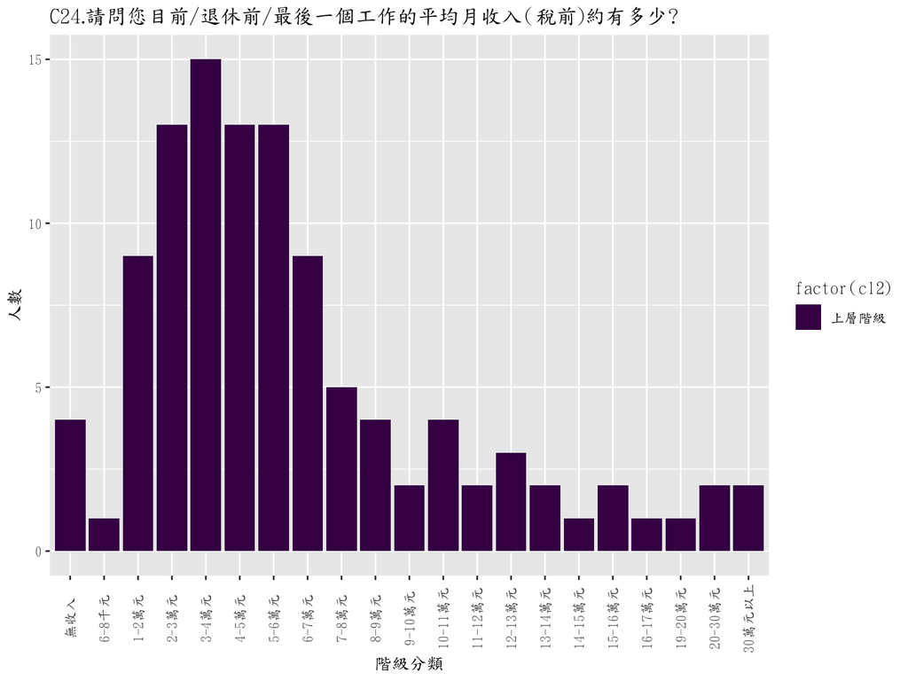

# 薪資分層

## 根據105年行政院每人每月薪資分布:四分位數

- 第 1 四分位數為 31,844 元
- 中位數 40,612元
- 第 3 四分位數為 55,091 元

# 根據105年四分位數的月薪分佈

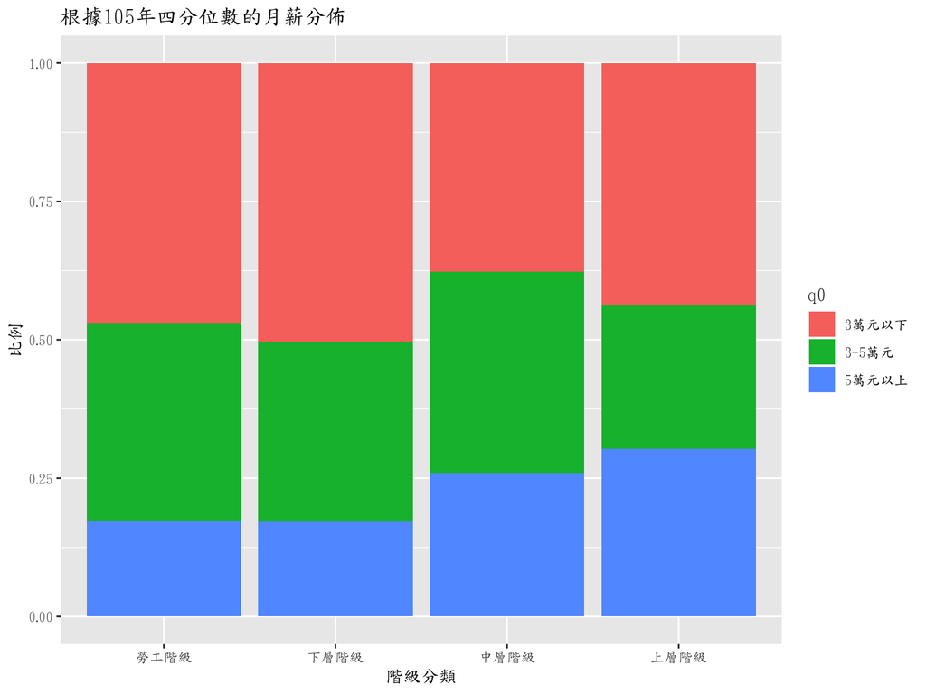

# 階層職業文字雲:全部階層

- 為了瞭解不同階層的職業，根據問題**C19.請問您目前(退休前/最後一個)職務為何?**做出不同階層的職業文字雲
- 此圖為所有階層的文字雲

[interactive chart not shown]

# 勞工、下層、中層、上層階級：職業文字雲

目前還沒有找到讓多個文字雲在同一份Ｒ Markdown文件裡展示的方法， 麻煩老師點開其他四分檔案查看結果QAQ

# 結語

- 從隨機森林機器學習結果來看： 原本認為可以藉由薪資、職業、快樂程度、對人的信任度來準確預測社會階級的結果，但是結果不如預期，一方面是因為職業總類過多無法列入考慮，依另一方面發現能夠幫助預測結果的項目是「父母的教育程度」和「家庭每月總收入」。似乎與階級複製的理論有異曲同工之妙，但是上層階級的預測錯誤率依然高達90％。因此，讓我深深的感受到找到歸類階級的答案並不是一個直觀而簡單的問題，可能要參考各項因素，或是從別的角度切入才可以找到接近的原因。
- 從快樂程度的結果來看：  
  原本以為快樂程度的直條圖並不會有明確的趨勢，但是結果出乎意料的顯示上階層的快樂程度比下階層來的高。但是這會不會是因為上階層的樣本數較少，相同的比例在下階層反而能彰顯的更清楚所造成的結果呢？
- 文字雲的結果來看：  
  文字雲也顛覆了我對於階層與職業刻板印象的認知。有點可惜目前沒有辦法將職業有效歸類，加入機器學習的變項，也許能夠幫助預測結果。
- 結論：  
  社會階級是一項複雜的議題，這是我從這一學期的分析作業最終意識到的道理。雖然沒有辦法找到「分類階級的原因」仍然幫助我了解到R的許多用法，也從資料視覺化了解到資料分析的有趣和廣大！

[interactive chart not shown]